# R程式知識整理

## 1.基本運算和陣列

```r
5+3
```

```
## [1] 8
```

```r
5/3
```

```
## [1] 1.666667
```

```r
5^3
```

```
## [1] 125
```

```r
5**3
```

```
## [1] 125
```

```r
5%%3
```

```
## [1] 2
```

```r
5%/%3
```

```
## [1] 1
```

```r
1:10
```

```
##  [1]  1  2  3  4  5  6  7  8  9 10
```

```r
seq(1, 10, 2)
```

```
## [1] 1 3 5 7 9
```

```r
seq(1, 10, length.out = 6)
```

```
## [1]  1.0  2.8  4.6  6.4  8.2 10.0
```

```r
abs(-2)
```

```
## [1] 2
```

```r
exp(10)
```

```
## [1] 22026.47
```

```r
log(2)
```

```
## [1] 0.6931472
```

```r
log2(2)
```

```
## [1] 1
```

```r
log(10)
```

```
## [1] 2.302585
```

```r
log10(10)
```

```
## [1] 1
```

## 2.一些取整函數

```r
round(125.78253)
```

```
## [1] 126
```

```r
round(125.78253, digits = -2)
```

```
## [1] 100
```

```r
round(83524587, digits = -3)
```

```
## [1] 83525000
```

```r
signif(125.78253, digits = 2)
```

```
## [1] 130
```

```r
signif(83524587, digits = 5)
```

```
## [1] 83525000
```

```r
floor(125.78253)
```

```
## [1] 125
```

```r
ceiling(125.78253)
```

```
## [1] 126
```

```r
trunc(125.78253)
```

```
## [1] 125
```

## 3.一些統計量會用到的（大概）

```r
x <- 1:25
print(x)
```

```
##  [1]  1  2  3  4  5  6  7  8  9 10 11 12 13 14 15 16 17 18 19 20 21 22 23 24 25
```

```r
mean(x)
```

```
## [1] 13
```

```r
var(x)
```

```
## [1] 54.16667
```

```r
median(x)
```

```
## [1] 13
```

```r
quantile(x, c(0.1, 0.5, 0.7))
```

```
##  10%  50%  70%
##  3.4 13.0 17.8
```

```r
x <- c(1:25, NA)
summary(x)
```

```
##    Min. 1st Qu.  Median    Mean 3rd Qu.    Max.    NA's
##       1       7      13      13      19      25       1
```

```r
mean(x, na.rm = TRUE)
```

```
## [1] 13
```

```r
var(x, na.rm = TRUE)
```

```
## [1] 54.16667
```

```r
median(x, na.rm = TRUE)
```

```
## [1] 13
```

```r
quantile(x, 0.5, na.rm = TRUE)
```

```
## 50%
##  13
```

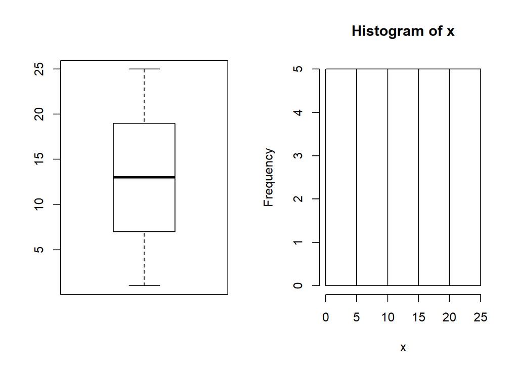

```r
par(mfrow = c(1, 2))
boxplot(x)
hist(x)
```

## 4.Vector

```r
vt1 <- c(1:5)
print(vt1)
```

```
## [1] 1 2 3 4 5
```

```r
vt2 <- c(3:6)
print(vt2)
```

```
## [1] 3 4 5 6
```

```r
vt2 <- c(vt2, vt1)
print(vt2)
```

```
## [1] 3 4 5 6 1 2 3 4 5
```

```r
length(vt2)
```

```
## [1] 9
```

```r
vt1[-2]
```

```
## [1] 1 3 4 5
```

```r
vt2[-c(3:6)]
```

```
## [1] 3 4 3 4 5
```

```r
rep(3, 12)
```

```
##  [1] 3 3 3 3 3 3 3 3 3 3 3 3
```

```r
rep(seq(2, 10, 2), 2)
```

```
##  [1]  2  4  6  8 10  2  4  6  8 10
```

```r
rep(seq(2, 10, 2), rep(3, 5))
```

```
##  [1]  2  2  2  4  4  4  6  6  6  8  8  8 10 10 10
```

```r
colors <- c("red", "yellow", "BLUE")
more.colors <- c(colors, "green", "cyan")
more.colors
```

```
## [1] "red"    "yellow" "BLUE"   "green"  "cyan"
```

```r
substr(more.colors, 1, 3)
```

```
## [1] "red" "yel" "BLU" "gre" "cya"
```

```r
grep("y", more.colors)
```

```
## [1] 2 5
```

```r
y.in.V <- grep("y", more.colors)
more.colors[y.in.V]
```

```
## [1] "yellow" "cyan"
```

```r
paste(colors, "line", sep = "" )
```

```
## [1] "redline"    "yellowline" "BLUEline"
```

```r
paste("I like", colors, collapse = "; ")
```

```
## [1] "I like red; I like yellow; I like BLUE"
```

## 5.Boolean operations

```r
A <- c(T, T, F, T, F); B <- c(3, 1, 5, 4, 7)
A
```

```
## [1]  TRUE  TRUE FALSE  TRUE FALSE
```

```r
B[A]
```

```
## [1] 3 1 4
```

```r
B[!A]
```

```
## [1] 5 7
```

```r
sum(A)
```

```
## [1] 3
```

### 另外有這些可以使用：

is.null() is.na() is.nan() is.infinite() is.character() is.integer() is.numeric()

## 6.matrix

```r
a <- 1:5; b <- 6:10;
c <- 11:15; d <- 16:20
M1 <- rbind(a,b,c,d)
M1
```

```
##   [,1] [,2] [,3] [,4] [,5]
## a    1    2    3    4    5
## b    6    7    8    9   10
## c   11   12   13   14   15
## d   16   17   18   19   20
```

```r
dim(M1)
```

```
## [1] 4 5
```

```r
colnames(M1) <- c("V1", "V2", "V3", "V4", "V5")
M1
```

```
##   V1 V2 V3 V4 V5
## a  1  2  3  4  5
## b  6  7  8  9 10
## c 11 12 13 14 15
## d 16 17 18 19 20
```

```r
M1[2, 4]; M1[4, 4];M1[c(2, 4), c(3, 5)]
```

```
## [1] 9
```

```
## [1] 19
```

```
##   V3 V5
## b  8 10
## d 18 20
```

```r
M1[, 4]; M1[4, ];M1[c(2, 4), ]
```

```
##  a  b  c  d
##  4  9 14 19
```

```
## V1 V2 V3 V4 V5
## 16 17 18 19 20
```

```
##   V1 V2 V3 V4 V5
## b  6  7  8  9 10
## d 16 17 18 19 20
```

```r
M2 <- cbind(a, b, c, d)
M2
```

```
##      a  b  c  d
## [1,] 1  6 11 16
## [2,] 2  7 12 17
## [3,] 3  8 13 18
## [4,] 4  9 14 19
## [5,] 5 10 15 20
```

```r
dim(M2)
```

```
## [1] 5 4
```

```r
X <- 1:20
matrix(X, nrow = 4, ncol = 5)
```

```
##      [,1] [,2] [,3] [,4] [,5]
## [1,]    1    5    9   13   17
## [2,]    2    6   10   14   18
## [3,]    3    7   11   15   19
## [4,]    4    8   12   16   20
```

```r
matrix(X, nrow = 5, ncol = 4)
```

```
##      [,1] [,2] [,3] [,4]
## [1,]    1    6   11   16
## [2,]    2    7   12   17
## [3,]    3    8   13   18
## [4,]    4    9   14   19
## [5,]    5   10   15   20
```

```r
matrix(X, nrow = 4, ncol = 5, byrow = TRUE)
```

```
##      [,1] [,2] [,3] [,4] [,5]
## [1,]    1    2    3    4    5
## [2,]    6    7    8    9   10
## [3,]   11   12   13   14   15
## [4,]   16   17   18   19   20
```

```r
matrix(X, nrow = 5, ncol = 4, byrow = TRUE)
```

```
##      [,1] [,2] [,3] [,4]
## [1,]    1    2    3    4
## [2,]    5    6    7    8
## [3,]    9   10   11   12
## [4,]   13   14   15   16
## [5,]   17   18   19   20
```

## 7.Control Flow

### Syntax:

#### for (**index** in vector) **commands**

##### index: the index is changed each time

##### vector: it includes all possible cases

##### commands: actions

### syntax:

#### if(condition) break

- #####The break statement causes the loop to terminate immediately. break statements can also be used in for() and while() loops.

### syntax:

#### repeat{ statements }

##### This causes the statements to be repeated endlessly.

### Syntax:

#### next:

##### The next statement causes control to return immediately to the top of the loop; it

- can also be used in any loop.

### Syntax:

#### if **(condition)** {commands when TRUE} (else{commands when FALSE})

##### The else part is optional, and provides an alternative set of commands

- which are to be invoked in case the logical variable is FALSE.

### Syntax:

#### while **(condition)** statements

##### If the condition evaluates to FALSE, nothing more is done. If it evaluates to

- TRUE the statements are executed, condition is evaluated again, and the process is repeated.

## 8.Function

#### 就手刻Function（大概）

## 9.Data Frame

### data.frame( )

##### Most data sets are stored in R as data frames.

##### These are like matrices, but with the columns having their own names.

##### Columns can be of different types from each other.

```r
colors <- c("red", "yellow", "blue")
numbers <- c(1, 2, 3)
colors.and.numbers <- data.frame(colors, numbers, more.numbers = c(4, 5, 6))
colors.and.numbers
```

```
##   colors numbers more.numbers
## 1    red       1            4
## 2 yellow       2            5
## 3   blue       3            6
```

```r
data2 <- data.frame(colors, numbers, more.numbers = c(4, 5, 6),
stringsAsFactors = FALSE)
data2 <- rbind(data2, c("black", 7, 8))
data2
```

```
##   colors numbers more.numbers
## 1    red       1            4
## 2 yellow       2            5
## 3   blue       3            6
## 4  black       7            8
```

## 10.Data input and output

#### Change the directory: **setwd(“dir”)**

#### Find the directory: **get()**

#### Suppose you have constructed some R objects, type **dump(objects, file = “XXX.R”)**

#### To retrieve the objects in a future session, type **source(“XXX.R”)**

#### To save all objects in the current workspace, type **save.image(“XXX.RData”)**

#### To save parts of objects, type **save(a, b, c, file = “XXX.RData”)**

#### Use **load(“XXX.RData”)** to retrieve data

### You can save a matrix, a vector, or a data frame into two types of file, .txt (.dat) and .csv.

#### Use **write.table(A, file = “XXX.txt”)**

#### Use **write.csv(A, file = “XXX.csv”)**

### You can laod a matrix, a vector, or a data frame from two types of file, .txt (.dat) and .csv.

#### Use **read.table(file = “XXX.txt”)**

#### Use **read.csv(file = “XXX.csv”)**

### If you read a data from a file with names of columns, you will get different input data of read.table() from that of read.csv().

### With names of columns in a .txt file, you should add **header = TRUE**

### To download a package, type **install.packages(“XXX”)**

### Before using some functions in a downloaded package, you should call the package by typing **library(XXX)**.